# PRECOVID BIC QC report: RNA-seq

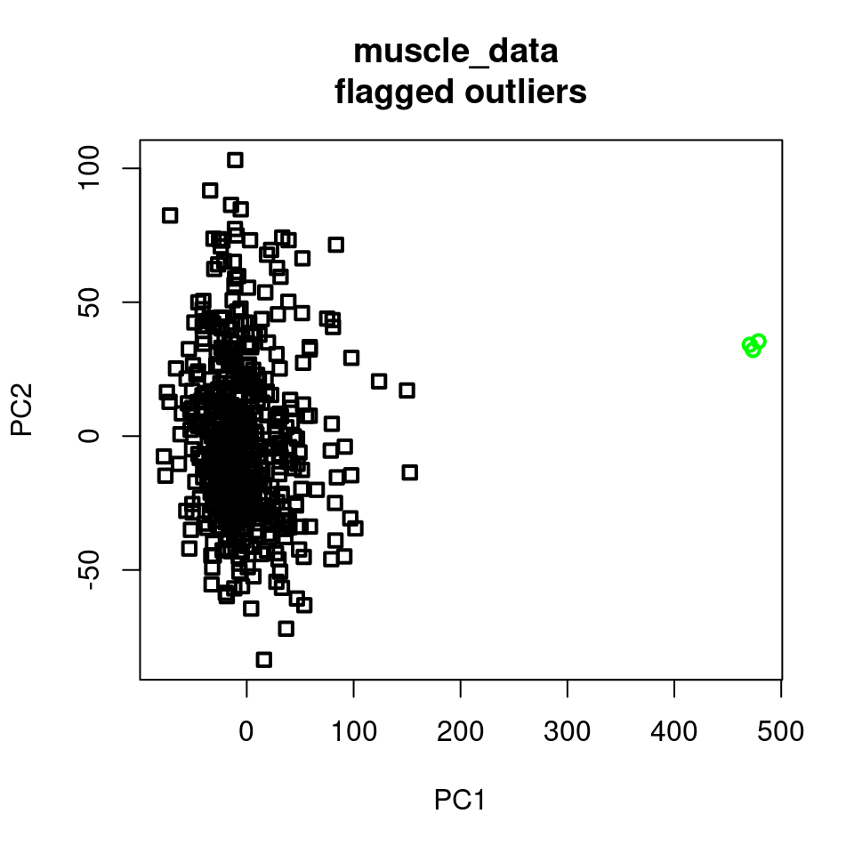

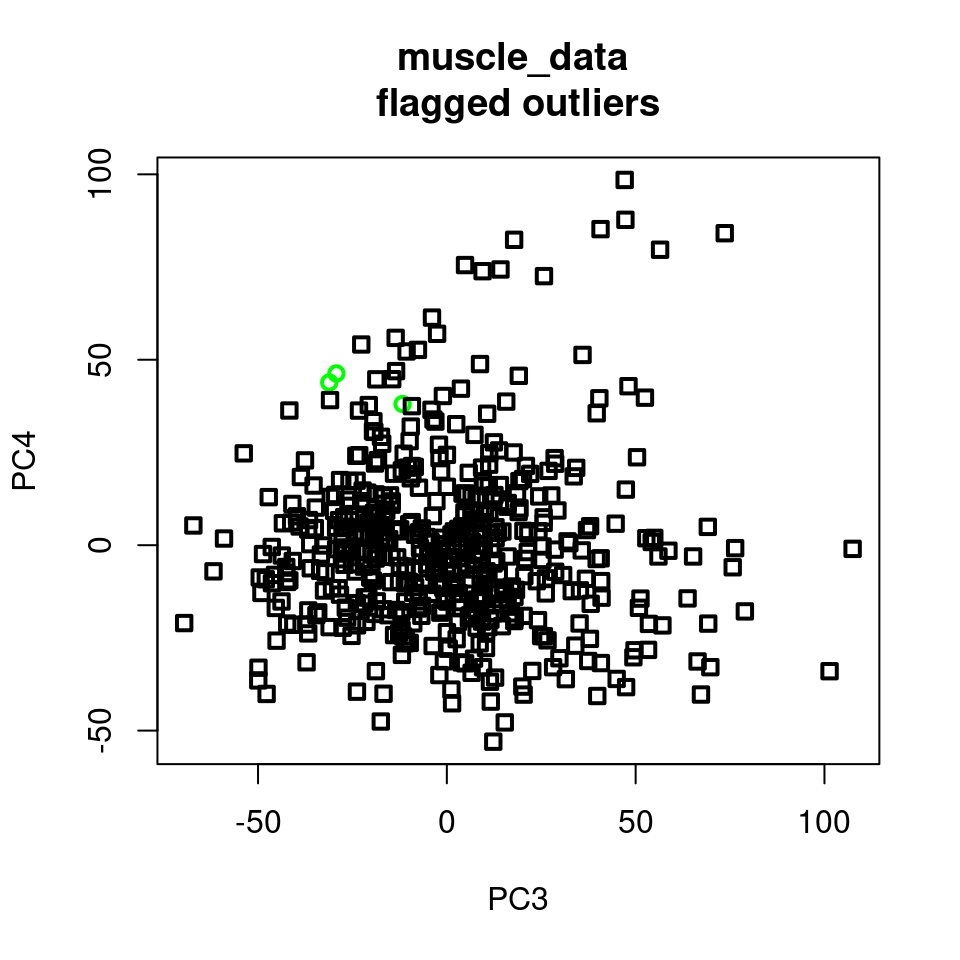

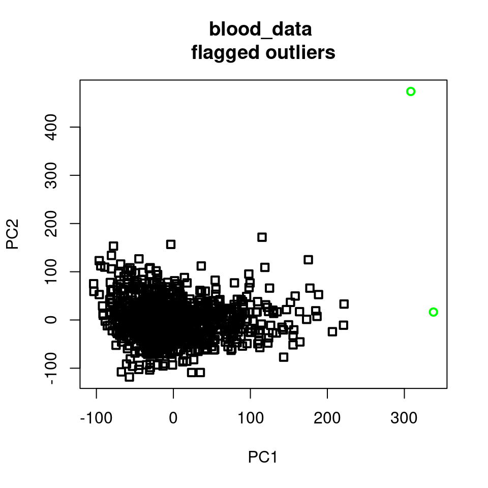

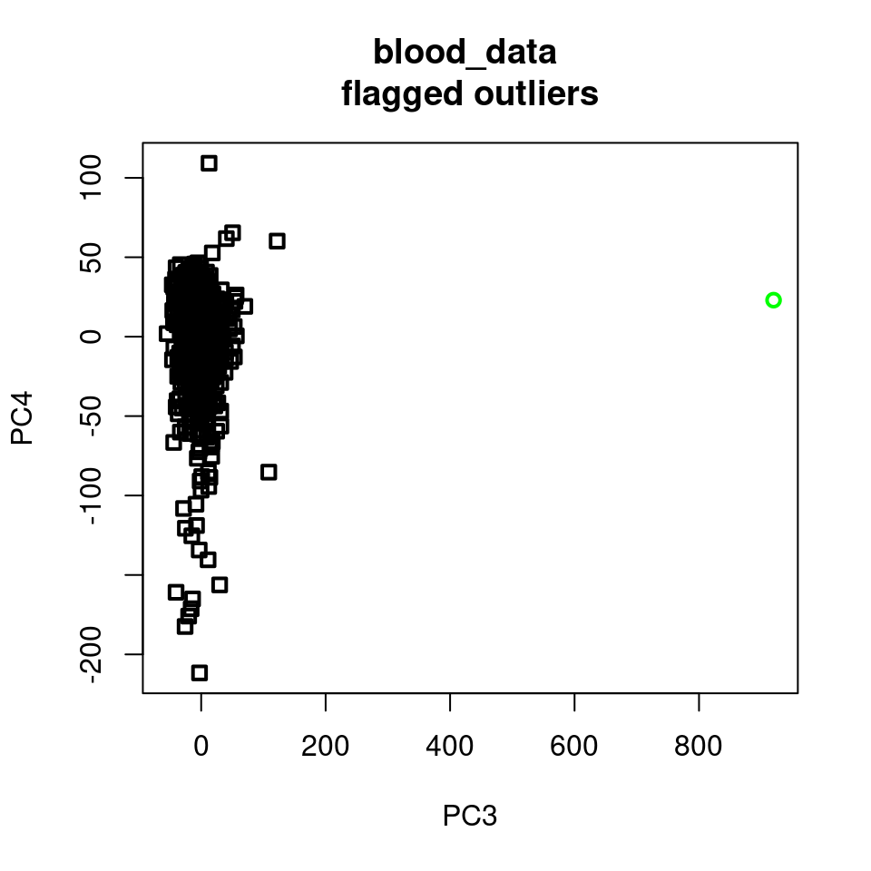

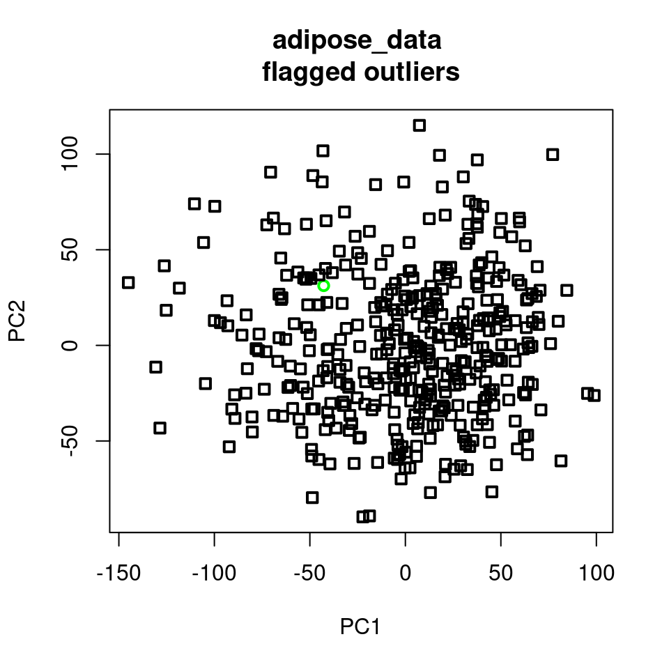

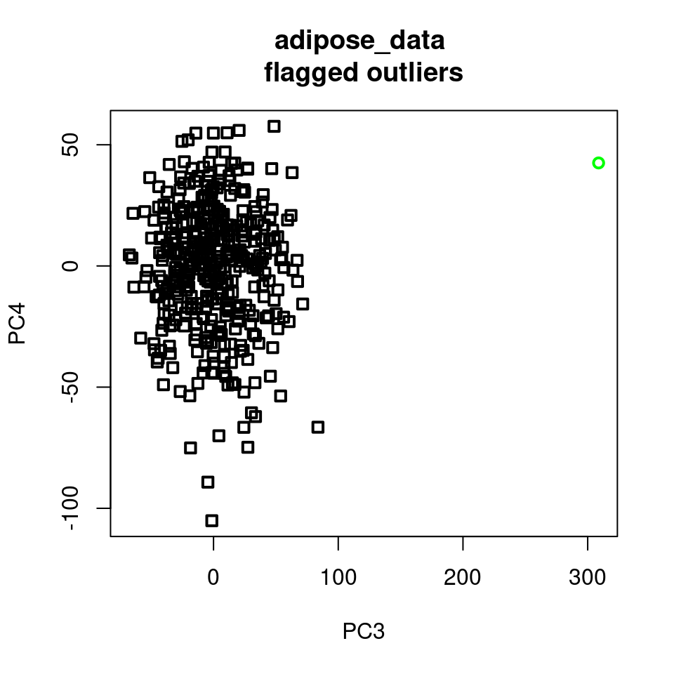

```r
pca_outliers_report = c()
for(currname in names(norm_rnaseq_data)){
  curr_pcax = norm_rnaseq_data[[currname]][["pca"]]
  # Univariate: use IQRs
  pca_outliers = c()
  for(j in 1:num_pcs_for_outlier_analysis){
    outlier_values <- boxplot.stats(curr_pcax[,j],coef = 5)$out
    for(outlier in names(outlier_values)){
      pca_outliers_report = rbind(pca_outliers_report,
                                  c(currname,paste("PC",j,sep=""),outlier,
                                    format(outlier_values[outlier],digits=5))
      )

      if(!is.element(outlier,names(pca_outliers))){
        pca_outliers[outlier] = outlier_values[outlier]
      }
    }
  }

  if(length(pca_outliers)>0){
    # print(length(kNN_outliers))
    df = data.frame(curr_pcax,
                    outliers = rownames(curr_pcax) %in% names(pca_outliers))
    col = rep("black",nrow(df))
    col[df$outliers] = "green"
    plot(df$PC1,df$PC2,pch = as.numeric(df$outliers),col=col,lwd=2,cex=1,
         main = paste(currname,"\nflagged outliers"),
         xlab = "PC1",ylab="PC2")
    plot(df$PC3,df$PC4,pch = as.numeric(df$outliers),col=col,lwd=2,cex=1,
         main = paste(currname,"\nflagged outliers"),
         xlab = "PC3",ylab="PC4")
  }
}
```

```r
if(!is.null(dim(pca_outliers_report))){
  colnames(pca_outliers_report) =  c("dataset","PC","sample","score")
}
pca_outliers_report
```

```
##      dataset        PC    sample        score
## [1,] "muscle_data"  "PC1" "11321030601" "473.59"
## [2,] "muscle_data"  "PC1" "11016030601" "478.71"
## [3,] "muscle_data"  "PC1" "11237010601" "470.57"
## [4,] "blood_data"   "PC1" "11097050401" "337.73"
## [5,] "blood_data"   "PC2" "11333010401" "473.89"
## [6,] "blood_data"   "PC3" "11333010401" "919.82"
## [7,] "adipose_data" "PC3" "11018021102" "308.75"
```

```r
pca_outliers = pca_outliers_report %>%
  as.data.frame() %>%
  dplyr::rename(Tissue = dataset) %>%
  dplyr::mutate(reason = interaction(PC, score)) %>%
  dplyr::mutate(Tissue = recode(Tissue,
                                "muscle_data" = "Muscle",
                                "blood_data" = "PaxGene RNA",
                                "adipose_data" = "Adipose")) %>%
  dplyr::select(sample, Tissue, reason)

mop_flagged = mop_flagged_samples %>%
  dplyr::rename(sample = vial_label) %>%
  dplyr::rename(reason = pipeline_flags)  %>%
  dplyr::select(sample, Tissue, reason)

full_outlier_report = rbind(pca_outliers, mop_flagged)
full_outlier_report <- full_outlier_report %>%
  group_by(sample, Tissue) %>%
  dplyr::summarize(reason = paste(reason, collapse = ", "), .groups = 'drop') %>%
  dplyr::arrange(reason)
full_outlier_report$reason = paste0("outlier, ", full_outlier_report$reason)

rownames(full_outlier_report) = NULL
head(full_outlier_report, 20)
```

| sample | Tissue | reason |
| --- | --- | --- |
| 11097050401 | PaxGene RNA | outlier, PC1.337.73, RIN<5 |
| 11237010601 | Muscle | outlier, PC1.470.57 |
| 11321030601 | Muscle | outlier, PC1.473.59 |
| 11016030601 | Muscle | outlier, PC1.478.71 |
| 11333010401 | PaxGene RNA | outlier, PC2.473.89, PC3.919.82, NumReads<20M |
| 11018021102 | Adipose | outlier, PC3.308.75 |
| 11005010401 | PaxGene RNA | outlier, RIN<5 |
| 11008010401 | PaxGene RNA | outlier, RIN<5 |
| 11008050401 | PaxGene RNA | outlier, RIN<5 |
| 11012020401 | PaxGene RNA | outlier, RIN<5 |
| 11019010401 | PaxGene RNA | outlier, RIN<5 |
| 11019050401 | PaxGene RNA | outlier, RIN<5 |
| 11038030401 | PaxGene RNA | outlier, RIN<5 |
| 11038070401 | PaxGene RNA | outlier, RIN<5 |
| 11042050401 | PaxGene RNA | outlier, RIN<5 |
| 11043010401 | PaxGene RNA | outlier, RIN<5 |
| 11043020401 | PaxGene RNA | outlier, RIN<5 |
| 11043030401 | PaxGene RNA | outlier, RIN<5 |
| 11043060401 | PaxGene RNA | outlier, RIN<5 |
| 11047020401 | PaxGene RNA | outlier, RIN<5 |

```r
for (tissue in unique(full_outlier_report$Tissue)){
  #here we now follow the "guidelines" name for clarity sake
  desired_adipose_name = "motrpac_human-precovid_t07-human-adipose_transcript-rna-seq_metadata_removed-samples_v1.txt"
  desired_muscle_name = "motrpac_human-precovid_t06-human-muscle_transcript-rna-seq_qc-metadata_removed-samples_v1.txt"
  desired_blood_name = "motrpac_human-precovid_t04-human-paxgene-rna_transcript-rna-seq_metadata_removed-samples_v1.txt"
  if (tissue == "Muscle"){outlier_output_name = desired_muscle_name}
  if (tissue == "Adipose"){outlier_output_name = desired_adipose_name}
  if (tissue == "PaxGene RNA"){outlier_output_name = desired_blood_name}

  outlier_output_local = paste0(repo_local_dir, "precovid-analyses/tmp/", outlier_output_name)
  outlier_sheet = full_outlier_report %>% dplyr::filter(Tissue == tissue)

  write.table(outlier_sheet, file = outlier_output_local, row.names = F, sep = "\t")
}
```

Here we do batch correction on the data with non-biological covariates and re-visualize the data after mean-centered regression to see potential relationships that may have been changed by the technical covariates. Lot of the same figures as above.

```r
outliers = full_outlier_report$sample
for (tissue in names(norm_rnaseq_data)){
  norm = norm_rnaseq_data[[tissue]]$norm_counts
  norm <- norm[, !colnames(norm) %in% outliers] #removing outliers
  meta = norm_rnaseq_data[[tissue]]$metadata
  meta <- meta[!rownames(meta) %in% outliers, ] #removing outliers

  meta$RIN = ifelse(is.na(meta$RIN), mean(meta$RIN, na.rm = T), meta$RIN)
  if(tissue == 'adipose_data'){
    batch_corrected = removeBatchEffect(norm,
                                        covariates=model.matrix(~RIN + clinical_site + pct_umi_dup, data = meta),
                                        design = model.matrix(~Sex + age + Timepoint + randomGroupCode, data = meta))
  }else{
    batch_corrected = removeBatchEffect(norm,
                                        covariates=model.matrix(~RIN + Batch + clinical_site + pct_umi_dup, data = meta),
                                        design = model.matrix(~Sex + age + Timepoint + randomGroupCode, data = meta))
  }

  norm_rnaseq_data[[tissue]]$batch_corrected = batch_corrected

  curr_pca = prcomp(t(batch_corrected),scale. = T,center = T)
  curr_pcax = curr_pca$x[,1:num_pcs]
  norm_rnaseq_data[[tissue]][["pca_corrected"]] = curr_pcax
  norm_rnaseq_data[[tissue]][["meta_no_outliers"]] = meta
}
```

```
## Coefficients not estimable: Timepointduring_20_min Timepointduring_40_min Timepointpost_10_min Timepointpost_30_min (Intercept)
```

```
## Coefficients not estimable: (Intercept)
```

```
## Coefficients not estimable: Timepointduring_20_min Timepointduring_40_min Timepointpost_10_min Timepointpost_15_min (Intercept)
```

```r
muscle_pcas_corrected = cbind(norm_rnaseq_data[['muscle_data']]$pca_corrected,norm_rnaseq_data[['muscle_data']]$meta_no_outliers)
blood_pcas_corrected = cbind(norm_rnaseq_data[['blood_data']]$pca_corrected,norm_rnaseq_data[['blood_data']]$meta_no_outliers)
adipose_pcas_corrected = cbind(norm_rnaseq_data[['adipose_data']]$pca_corrected,norm_rnaseq_data[['adipose_data']]$meta_no_outliers)
```

```r
C_blood = canCorPairs(form, blood_pcas_corrected)
C_muscle = canCorPairs(form, muscle_pcas_corrected)
C_adipose = canCorPairs(form, adipose_pcas_corrected)
rownames(C_blood) <- colnames(C_blood) <- interesting_variables
rownames(C_muscle) <- colnames(C_muscle) <- interesting_variables
rownames(C_adipose) <- colnames(C_adipose) <- interesting_variables
```

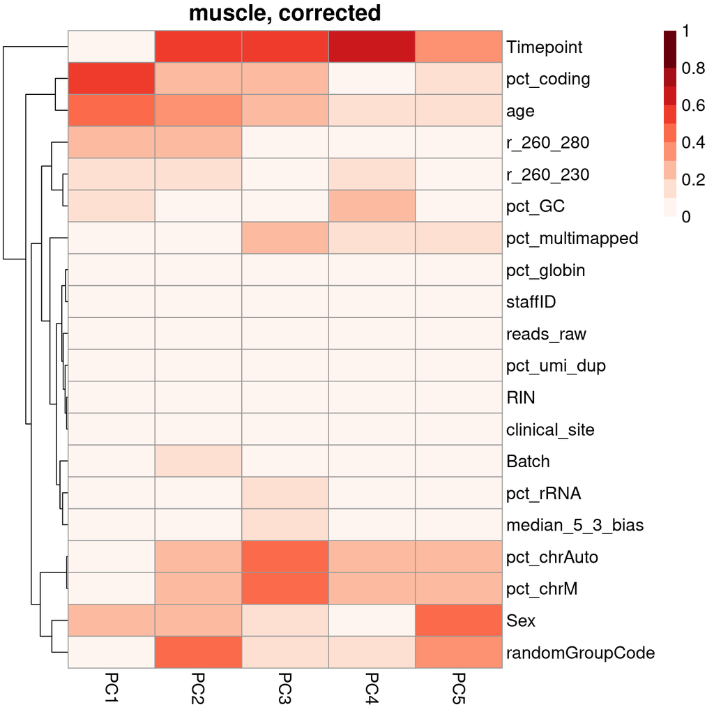

```r
coul <- brewer.pal(9, "Reds")
pcs <- c("PC1","PC2","PC3","PC4","PC5")
breaksList = seq(0, 1.00, by = 0.1)
pheatmap(C_muscle[!rownames(C_muscle) %in% pcs,pcs],color=coul,breaks=breaksList,fontsize = 14, cluster_cols = F, main = "muscle, corrected")
```

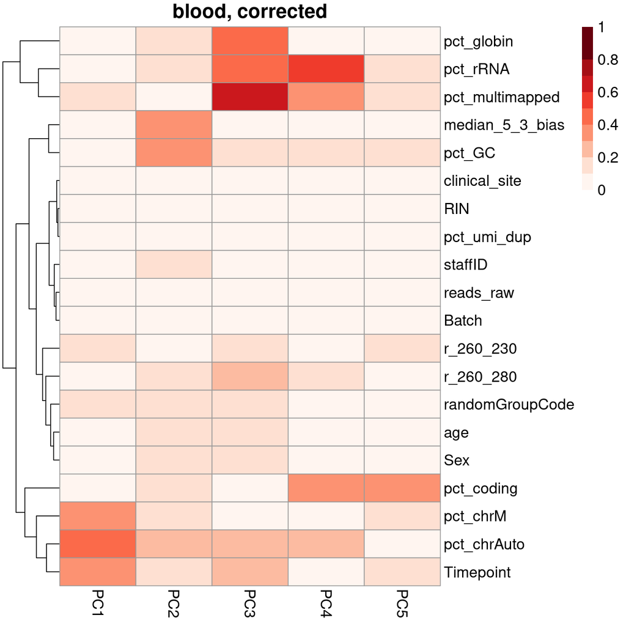

```r
pheatmap(C_blood[!rownames(C_blood) %in% pcs,pcs],color=coul,breaks=breaksList,fontsize = 14, cluster_cols = F, main = "blood, corrected")
```

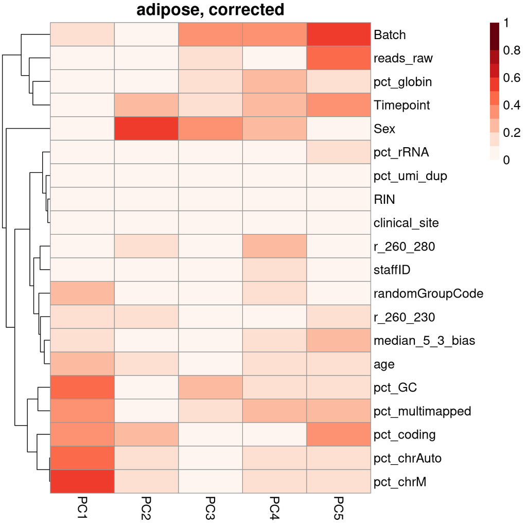

```r
pheatmap(C_adipose[!rownames(C_adipose) %in% pcs,pcs],color=coul,breaks=breaksList,fontsize = 14, cluster_cols = F, main = "adipose, corrected")
```

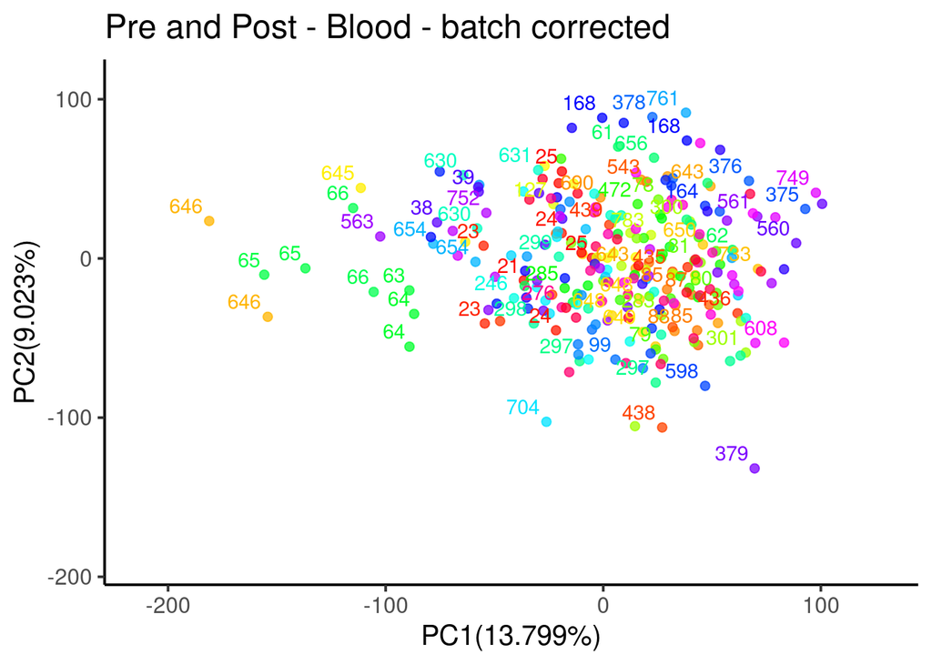

```r
blood_pcas_corrected <- blood_pcas_corrected %>%
  dplyr::select(PC1, PC2, PC3, PC4, PC5, participant_id, Timepoint) %>%
  dplyr::group_by(participant_id, Timepoint) %>%
  dplyr::mutate(duplicate_group = if (n() > 1) cur_group_id() else NA_integer_) %>%
  dplyr::ungroup() %>%
  dplyr::mutate(duplicate_label = ifelse(!is.na(duplicate_group), as.character(duplicate_group), NA))

unique_duplicates <- unique(blood_pcas_corrected$duplicate_group[!is.na(blood_pcas_corrected$duplicate_group)])
custom_palette <- c("black", setNames(rainbow(length(unique_duplicates)), unique_duplicates))

ggplot(data = blood_pcas_corrected, aes(x = PC1, y = PC2, color = as.factor(duplicate_group))) +
  geom_point(size = 2, alpha = 0.75) +
  geom_text(aes(label = duplicate_label), check_overlap = T, hjust = 1.2, vjust = -0.5) +
  ylim(c(-190, 110)) +
  scale_color_manual(values = custom_palette, na.translate = FALSE) +
  theme_classic(base_size = 15) +
  labs(color = "Duplicate Group", title = "Pre and Post - Blood - batch corrected", x = paste("PC1", "(", var_exp[1], "%)", sep = ""), y = paste("PC2", "(", var_exp[2], "%)", sep = ""))  +
  theme(legend.position = "none")
```

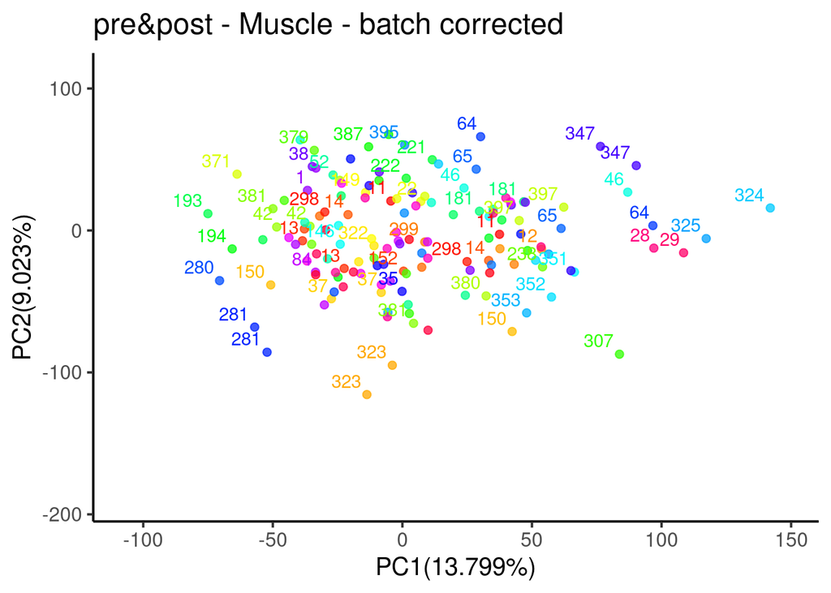

```r
muscle_pcas_corrected <- muscle_pcas_corrected %>%
  dplyr::select(PC1, PC2, PC3, PC4, PC5, participant_id, Timepoint) %>%
  dplyr::group_by(participant_id, Timepoint) %>%
  dplyr::mutate(duplicate_group = if (n() > 1) cur_group_id() else NA_integer_) %>%
  dplyr::ungroup() %>%
  dplyr::mutate(duplicate_label = ifelse(!is.na(duplicate_group), as.character(duplicate_group), NA))

unique_duplicates <- unique(muscle_pcas_corrected$duplicate_group[!is.na(muscle_pcas_corrected$duplicate_group)])
custom_palette <- c("black", setNames(rainbow(length(unique_duplicates)), unique_duplicates))

ggplot(data = muscle_pcas_corrected, aes(x = PC1, y = PC2, color = as.factor(duplicate_group))) +
  geom_point(size = 2, alpha = 0.75) +
  geom_text(aes(label = duplicate_label), check_overlap = TRUE, hjust = 1.2, vjust = -0.5) +
  ylim(c(-190, 110)) +
  scale_color_manual(values = custom_palette, na.translate = FALSE) +
  theme_classic(base_size = 15) +
  labs(color = "Duplicate Group", title = "pre&post - Muscle - batch corrected", x = paste("PC1", "(", var_exp[1], "%)", sep = ""), y = paste("PC2", "(", var_exp[2], "%)", sep = ""))  +
  theme(legend.position = "none")
```

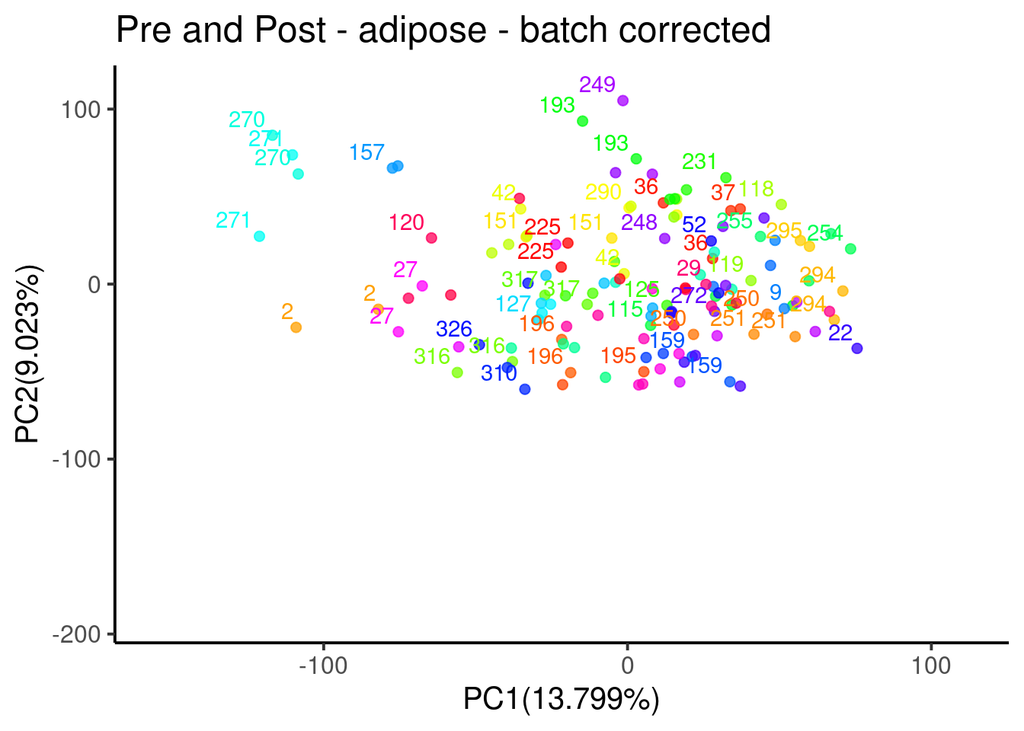

```r
adipose_pcas_corrected <- adipose_pcas_corrected %>%
  dplyr::select(PC1, PC2, PC3, PC4, PC5, participant_id, Timepoint) %>%
  dplyr::group_by(participant_id, Timepoint) %>%
  dplyr::mutate(duplicate_group = if (n() > 1) cur_group_id() else NA_integer_) %>%
  dplyr::ungroup() %>%
  dplyr::mutate(duplicate_label = ifelse(!is.na(duplicate_group), as.character(duplicate_group), NA))

unique_duplicates <- unique(adipose_pcas_corrected$duplicate_group[!is.na(adipose_pcas_corrected$duplicate_group)])
custom_palette <- c("black", setNames(rainbow(length(unique_duplicates)), unique_duplicates))

ggplot(data = adipose_pcas_corrected, aes(x = PC1, y = PC2, color = as.factor(duplicate_group))) +
  geom_point(size = 2, alpha = 0.75) +
  geom_text(aes(label = duplicate_label), check_overlap = T, hjust = 1.2, vjust = -0.5) +
  ylim(c(-190, 110)) +
  scale_color_manual(values = custom_palette, na.translate = FALSE) +
  theme_classic(base_size = 15) +
  labs(color = "Duplicate Group", title = "Pre and Post - adipose - batch corrected", x = paste("PC1", "(", var_exp[1], "%)", sep = ""), y = paste("PC2", "(", var_exp[2], "%)", sep = ""))  +
  theme(legend.position = "none")
```

Here we actually output the norm counts sheets with outliers removed for the data freeze, to give other analysts the norm counts

```r
for (tissue in names(norm_rnaseq_data)){
  #here we now follow the "guidelines" name for clarity sake
  desired_adipose_name = "motrpac_human-precovid_t07-human-adipose_transcript-rna-seq_qc-norm_tmm-scaled_v1.txt"
  desired_muscle_name = "motrpac_human-precovid_t06-human-muscle_transcript-rna-seq_qc-norm_tmm-scaled_v1.txt"
  desired_blood_name = "motrpac_human-precovid_t04-human-paxgene-rna_transcript-rna-seq_qc-norm_tmm-scaled_v1.txt"
  if (tissue == "muscle_data"){qc_output_name = desired_muscle_name}
  if (tissue == "adipose_data"){qc_output_name = desired_adipose_name}
  if (tissue == "blood_data"){qc_output_name = desired_blood_name}
  qc_output_local = paste0(repo_local_dir, "precovid-analyses/tmp/", qc_output_name)
  #the batch corrected version already has outliers removed
  write.table(norm_rnaseq_data[[tissue]]$batch_corrected, file = qc_output_local, row.names = T, sep = "\t")
}
```

repeat for printing metadata for samples

```r
for (tissue in names(norm_rnaseq_data)){
  #here we now follow the "guidelines" name for clarity sake
  desired_adipose_name = "motrpac_human-precovid_t07-human-adipose_transcript-rna-seq_metadata_samples_v1.txt"
  desired_muscle_name = "motrpac_human-precovid_t06-human-muscle_transcript-rna-seq_metadata_samples_v1.txt"
  desired_blood_name = "motrpac_human-precovid_t04-human-paxgene-rna_transcript-rna-seq_metadata_samples_v1.txt"
  if (tissue == "muscle_data"){meta_output_name = desired_muscle_name}
  if (tissue == "adipose_data"){meta_output_name = desired_adipose_name}
  if (tissue == "blood_data"){meta_output_name = desired_blood_name}
  meta_output_local = paste0(repo_local_dir, "precovid-analyses/tmp/", meta_output_name)

  rm_col = c("BMI", "BMI_groups", "Age_groups", "Age_3_groups", "BID")
  meaningful_meta = norm_rnaseq_data[[tissue]]$meta_no_outliers %>%
    as.data.frame() %>%
    dplyr::select(-all_of(rm_col))
  #the batch corrected version already has outliers removed
  write.table(meaningful_meta, file = meta_output_local, row.names = F, sep = "\t")
}
```